# Project Report IE 582

# 2 Literature Review

**Class Imbalance in Classification Problem**

Class imbalance is the situation where a class of predicted variable is significantly higher than the other one/s. In binary classification case, the class with higher number of observations is called “majority class” and the other is called “minority class.” This is a common problem in real life data where a class may naturally dominate the other ones, or it may be a result of biased sampling or measurement errors (Brownlee, 2019). This class imbalance problem has to be dealt in order Machine Learning algorithms to perform better on balanced prediction accuracy. There are various methods to deal with class imbalance and the ones considered in this study are over-sampling, under-sampling and Synthetic Minority Over-sampling Technique (SMOTE). Each of these methods follows a different approach to balance the number of observations among classes (Barandela et al., 2004).

**Over-sampling**

Over-sampling is basically replicating observations from the minority class using different methods. Using Nearest Neighbor approach on the minority data, an amount of artificial observations is created and added to the dataset in order to balance the class distributions (Barandela et al., 2004). Creation of new data can be done randomly or by “informative sampling” using “pre-defined criterion” to obtain new data for the minority class. One great advantage of over-sampling is that no data is lost, so there will not be any loss of information due to data removed. On the other hand, obtaining new observations from the minority data by replicating them following a pattern may cause overfitting (“Analytics Vidhya”, 2016). These advantage and disadvantage have to be discussed thoroughly before implementing the method.

We will use Synthetic Minority Over-sampling Technique (SMOTE) function from “smotefamily” package in order to implement this method in R.

**Under-sampling**

Under-sampling is again basically removing observations from the majority class in order to balance the class distributions in the dataset. Removing observations from the original data eventually causes loss of information so there are some algorithms developed to reduce the loss of significant information while removing samples from the data. Wilson’s Editing, Weighted Editing and The Modified Selective Subsets are some algorithms focusing on removing the observations with minimum loss of significant information (Barandela et al., 2004). One important disadvantage of under-sampling is loss of information and training the model with less data. This may lead to lower accuracy of prediction in the final predictive model. “ovun.sample()” function in “ROSE” package can be used to implement both over- and under- sampling in R.

**Mixture of Over-Sampling and Under-Sampling**

SMOTE from DMwR package is a method which integrates the previously discussed methods, over-sampling and under-sampling. The majority class is under-sampled, and the minority class is over-sampled to a level which optimizes the loss of information and overfitting. SMOTE from DMwR proposes an over-sampling approach of creating “synthetic” instead of over-sampling by replacement (Chawla et al., 2002). Chawla et al. states that this approach gives better ROC results in various datasets (2002). But this may still lead to information loss.

# 3 Approach

```r
# make all colns double for smote
train_y <- mlr::createDummyFeatures(train$y, train$y,  method="reference")
trainx <- train %>% select(-y)
train <- cbind(as.data.table(trainx), as.data.table(train_y)) %>% rename(y=b)

set.seed(70)
smote <- smotefamily::SMOTE(X=train, target=train$y, K=1, dup_size = 2)

final_train_smote <- smote[["data"]] %>% select(-class)
class_dist2 <- final_train_smote %>% group_by(y) %>% summarize(count=n())

final_train_smote$y[final_train_smote$y==1] <- "b"
final_train_smote$y[final_train_smote$y==0] <- "a"
```

In order to use `SMOTE` function from `smotefamily` package, we map the target column to 0-1 from a-b. We do this by creating dummies. Then we use `SMOTE` to increase the instances from the minority class and make the data balanced. We observe that there are 1565 many a’s and 1527 many b’s. The number of instances from each class are very close, so the imbalance problem is fixed. Then we map 0-1’s to a-b in order to avoid possible errors with Random Forest Classifier.

```r
# scaling
train_cts_scaled <- final_train_smote %>% select(-y) %>% select(cts_features) %>% scale() %>% as.data.frame()

X_test_cts_scaled <-X_test_submission %>% select(cts_features) %>% scale() %>% as.data.frame()

# factorization
train_categorical <- final_train_smote %>% select(categorical_features)
train_categorical <- lapply(train_categorical, factor)
X_test_submission_categorical <- X_test_submission %>% select(categorical_features)
X_test_submission_categorical <- lapply(X_test_submission_categorical, factor)

train_categorical <- final_train_smote %>% select(categorical_features)

X_test_submission_categorical <- X_test_submission %>% select(categorical_features)

# scaled and factored
trainn <- cbind(as.data.table(train_cts_scaled), as.data.table(train_categorical), as.data.table(final_train_smote$y)) %>% rename(y=V1)
trainn$y <- as.factor(trainn$y)
final_train <- trainn
X_test_submission <- cbind(as.data.table(X_test_cts_scaled), as.data.table(X_test_submission_categorical))
```

In order to treat continuous and categorical features differently, we created separate dataframes. Since some of the features are continuous, we normalized them using `scale` function. We also have binary categorical features that need to be factorized. Then we binded the dataframes back. This procedure is done for both train and test feature datasets.

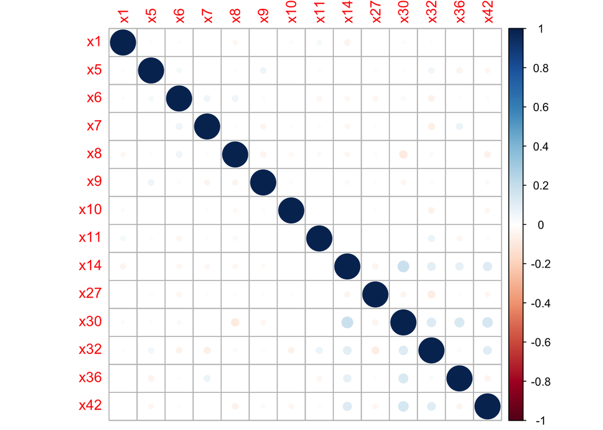

```r
#Correlation check
corrplot(cor(train_cts_scaled, method = c("pearson")))
```

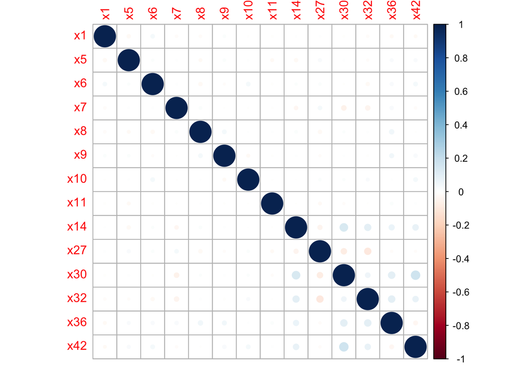

```r
corrplot(cor(X_test_cts_scaled, method = c("pearson")))
```

Correlation makes sense only for the continuous features. Here we see that, none of the continuous variables are significantly correlated. As a result, we do not remove any of the continuous variables from the train data.

```r
a <- model_RF[["finalModel"]][["variable.importance"]] %>% as.data.frame()
colnames(a)[1] = "Importance"
a <- a %>% arrange(desc(Importance)) %>% tail(10)
print(a)
```

```
FALSE        Importance
FALSE x18  6.008632e-04
FALSE x55  3.663134e-04
FALSE x13  2.533473e-04
FALSE x60  2.443974e-04
FALSE x29  2.441956e-04
FALSE x46  3.006047e-05
FALSE x59  5.881240e-06
FALSE x26  4.795239e-06
FALSE x49 -7.627345e-06
FALSE x43 -1.130418e-05
```

We would like to use permutation based importance since it accounts for noisy data better and multiple permutation trials are better than single shuffle. Recall that due to shuffling, processing is not simultaneous. We used Ranger Classifier in order to see the permutation based importance of the features. It gives 99.84% on train data. We order the features according to their permutation based importance and decide to eliminate last 10 least important ones from our models.